# Homework 03

## Question 1: Build an `explain-to-me` skill

Create a small skill named `explain-to-me` that helps you understand a homework question.

1. Design your `SKILL.md` file so that, when you explicitly ask your agent to use the skill to read a homework question, the agent communicates with you and explains what the question is asking.
2. Keep the skill file short. It should contain a few useful rules, instructions, and a clear statement of your intent. For example, you may ask the agent to explain the goal of the question, clarify what work is required, and point you to an appropriate section of the Week 3 lectures: [Ridge Regression: Stability Through Shrinkage](https://teazrq.github.io/stat432rpy/topics/ridge-regression/ridge-regression.html) or [From a Penalized Objective to a Fitted Ridge Model](https://teazrq.github.io/stat432rpy/topics/ridge-regression/optimization-and-cross-validation.html). The skill should help you understand the question without completing the solution for you.
3. Create the skill yourself or with the help of AI. Save it as `explain-to-me/SKILL.md`. Then ask your AI agent to install the skill using its normal skill-installation method. Test it by explicitly asking the agent to use `explain-to-me` to read and explain Question 2.
4. If the skill does not work well, or if it begins to disturb your usual workflow, ask your agent to remove the installed skill. You may revise and reinstall it if you wish.
5. In all cases, append the complete contents of your developed `explain-to-me/SKILL.md` file at the end of your Homework 3 submission under the heading **`explain-to-me` skill**.

## Question 2: Ridge regression with nearly collinear predictors

Let $n=100$. Generate mutually independent standard normal random variables

$$L_i, U_{i1}, U_{i2}, X_{i3}, X_{i4},
\qquad i=1,\ldots,n,$$

and define

$$X_{i1}=L_i+0.04U_{i1},
\qquad
X_{i2}=L_i+0.04U_{i2}.$$

Center and standardize each column of $\mathbf X$ to have mean zero and average squared value one, following the [lecture’s scaling convention](https://teazrq.github.io/stat432rpy/topics/ridge-regression/ridge-regression.html#put-every-covariate-on-a-common-scale).

Continue to use $\mathbf X\in\mathbb R^{n\times p}$ for the standardized matrix and keep it fixed throughout the question, where $p=4$ is the number of predictors. The unpenalized intercept gives $p+1=5$ total fitted coefficients. Let

$$\boldsymbol\beta
=
(1.5,1.5,1,0)^{\mathsf T},
\qquad
\boldsymbol\mu
=
\mathbf X\boldsymbol\beta.$$

Generate a training response and an independent test response at the same predictor values:

$$\begin{aligned}
\mathbf y
&=
\boldsymbol\mu+\boldsymbol\epsilon,\\
\mathbf y^*
&=
\boldsymbol\mu+\boldsymbol\epsilon^*,
\end{aligned}$$

where

$$\boldsymbol\epsilon,
\boldsymbol\epsilon^*
\overset{\mathrm{ind}}{\sim}
\mathcal N_n(\mathbf0,\mathbf I_n).$$

Center the training response as $\widetilde{\mathbf y}=\mathbf y-\bar y\mathbf1_n$. For each $\lambda\in\{0,0.02,0.2\}$, fit the slopes using the lecture’s ridge formula:

$$\widehat{\boldsymbol\beta}_\lambda
=
\left(\mathbf X^{\mathsf T}\mathbf X+n\lambda\mathbf I_p\right)^{-1}
\mathbf X^{\mathsf T}\widetilde{\mathbf y}.$$

The unpenalized intercept is $\widehat\beta_0=\bar y$; add this training mean back when predicting either response. The case $\lambda=0$ is ordinary least squares. Use seed `43231` before generating the design and responses. R and Python use different random-number generators, so their exact numerical results need not agree.

1. Generate $\mathbf X$ once. Report the correlation between its first two columns and its largest and smallest singular values. Use these quantities to explain why the estimator contrast $\widehat\beta_1-\widehat\beta_2$ should be much more variable than $\widehat\beta_1+\widehat\beta_2$.
2. Independently repeat the generation of $\mathbf y$ and $\mathbf y^*$, followed by all three fits, 200 times while keeping $\mathbf X$ fixed. Draw the training and test noise inside each repetition, then reuse that realized pair for all three values of $\lambda$. For each value of $\lambda$, report the empirical mean and standard deviation of

$$\widehat\beta_1,
\quad
\widehat\beta_2,
\quad
\widehat\beta_1+\widehat\beta_2,
\quad
\widehat\beta_1-\widehat\beta_2.$$

Also report the average training MSE and the average test MSE calculated from the independent test response, where

$$\operatorname{MSE}_{\mathrm{test}}
=
\frac{1}{n}
\left\lVert
\mathbf y^*
-
\widehat\beta_0\mathbf1_n
-
\mathbf X\widehat{\boldsymbol\beta}
\right\rVert_2^2.$$

3. Interpret the coefficient estimates and test MSE using bias and variance. Explain why ridge can substantially stabilize the individual coefficients without producing an equally large change in the fitted values.

### Solution: Question 2

**Show the workflow**

```r
set.seed(43231)

n <- 100

L <- rnorm(n)
U1 <- rnorm(n)
U2 <- rnorm(n)
X3 <- rnorm(n)
X4 <- rnorm(n)

X1 <- L + 0.04 * U1
X2 <- L + 0.04 * U2

X_raw <- cbind(
  x1 = X1,
  x2 = X2,
  x3 = X3,
  x4 = X4
)

x_bar <- colMeans(X_raw)

X <- sweep(X_raw, 2, x_bar, "-")

s <- sqrt(colMeans(X^2))

X <- sweep(X, 2, s, "/")

cor(X[, "x1"], X[, "x2"])
```

```
[1] 0.9977057
```

**Show the workflow**

```r
sv <- svd(X)$d
sv
```

```
[1] 14.1414804 10.3477319  9.6289673  0.4753575
```

**Show the workflow**

```r
max(sv)
```

```
[1] 14.14148
```

**Show the workflow**

```r
min(sv)
```

```
[1] 0.4753575
```

**Show the workflow**

```r
beta <- c(1.5, 1.5, 1, 0)

mu <- X %*% beta

lambdas <- c(0, 0.02, 0.2)
B <- 200

beta1_results <- matrix(NA, nrow = B, ncol = length(lambdas))
beta2_results <- matrix(NA, nrow = B, ncol = length(lambdas))
sum_results   <- matrix(NA, nrow = B, ncol = length(lambdas))
diff_results  <- matrix(NA, nrow = B, ncol = length(lambdas))

train_mse <- matrix(NA, nrow = B, ncol = length(lambdas))
test_mse  <- matrix(NA, nrow = B, ncol = length(lambdas))

for (b in 1:B) {

  eps <- rnorm(n)
  eps_star <- rnorm(n)

  y <- mu + eps
  y_star <- mu + eps_star

  y_bar <- mean(y)
  y_tilde <- y - y_bar

  for (j in 1:length(lambdas)) {

    lambda <- lambdas[j]

    beta_hat <- solve(
      t(X) %*% X + n * lambda * diag(ncol(X)),
      t(X) %*% y_tilde
    )

    beta1_results[b, j] <- beta_hat[1]
    beta2_results[b, j] <- beta_hat[2]

    sum_results[b, j] <- beta_hat[1] + beta_hat[2]
    diff_results[b, j] <- beta_hat[1] - beta_hat[2]

    y_hat <- y_bar + X %*% beta_hat

    train_mse[b, j] <- mean((y - y_hat)^2)
    test_mse[b, j] <- mean((y_star - y_hat)^2)
  }
}

results <- data.frame(
  lambda = lambdas,
  mean_beta1 = colMeans(beta1_results),
  sd_beta1 = apply(beta1_results, 2, sd),
  mean_beta2 = colMeans(beta2_results),
  sd_beta2 = apply(beta2_results, 2, sd),
  mean_sum = colMeans(sum_results),
  sd_sum = apply(sum_results, 2, sd),
  mean_diff = colMeans(diff_results),
  sd_diff = apply(diff_results, 2, sd)
)

results$mean_train_mse <- colMeans(train_mse)
results$mean_test_mse <- colMeans(test_mse)

results
```

```
  lambda mean_beta1   sd_beta1 mean_beta2   sd_beta2 mean_sum     sd_sum
1   0.00   1.495589 1.54394848   1.509765 1.54858847 3.005354 0.09510778
2   0.02   1.486994 0.16151331   1.489176 0.16591120 2.976171 0.09416526
3   0.20   1.367908 0.04570277   1.368693 0.04733702 2.736601 0.08646679
     mean_diff    sd_diff mean_train_mse mean_test_mse
1 -0.014175478 3.09107762      0.9647563      1.062452
2 -0.002181997 0.31362247      0.9746809      1.049262
3 -0.000785071 0.03438848      1.0767603      1.133484
```

The correlation between X1 and X2 is 0.9977057, which means that the two predictors were nearly perfectly correlated. The largest singular value of X is 14.14148 and the smallest singular value was 0.4753575. The very small singular value indicates that there is a direction in the predictor space that is weakly identified. Because X1 and X2 are nearly identical, their combined effect is much easier to estimate than their individual effects. Therefore, $\hat{\beta}_1-\hat{\beta}_2$ should have much greater sampling variability than $\hat{\beta}_1+\hat{\beta}_2$, since large changes in the individual coefficients can offset each other while producing similar fitted values.

Across the 200 repetitions, ridge regression greatly reduced the variability of the coefficient estimates. The standard deviation of $\hat{\beta}_1-\hat{\beta}_2$ decreased from 3.0911 when $\lambda=0$ to 0.3136 when $\lambda=0.02$ and 0.0344 when $\lambda=0.20$. Meanwhile, the standard deviation of $\hat{\beta}_1+\hat{\beta}_2$ stayed much more consistent across the three values of $\lambda$. The average test MSE was lowest when $\lambda=0.02$, at 1.0493, compared to 1.0625 for $\lambda=0$ and 1.1335 for $\lambda=0.20$.

The results show the tradeoff between bias and variance when using ridge regression. When $\lambda=0$, the individual coefficient estimates have a lot of variability because $X_1$ and $X_2$ are nearly identical. As $\lambda$ increases, the variability of these estimates decreases significantly, but the estimates also become more biased. For example, the mean of $\hat{\beta}_1$ decreased from 1.4956 to 1.3679 even though the true value is 1.5. A small amount of ridge improved the test MSE from 1.0625 to 1.0493 because the reduction in variance was worth the small increase in bias. However, when $\lambda=0.20$, the test MSE increased to 1.1335 because the stronger shrinkage introduced more bias. Ridge also makes the individual coefficients much more stable without changing the fitted values as much because $X_1$ and $X_2$ are so similar that their combined effect is more important for prediction than how that effect is divided between the two coefficients.

## Question 3: What does ridge regression shrink?

Let $\mathbf X\in\mathbb R^{n\times p}$ be a centered predictor matrix, and let $\widetilde{\mathbf y}\in\mathbb R^n$ be the centered response. Use the supplied predictor scales for this algebraic question; the columns need not have unit variance. Here $p$ counts predictors, $\boldsymbol\beta\in\mathbb R^p$ contains their slopes, and $p+1$ counts all fitted coefficients, including the separately fitted, unpenalized intercept. Ridge regression minimizes

$$L_\lambda(\boldsymbol\beta)
=
\frac{1}{2n}
\left\lVert
\widetilde{\mathbf y}-\mathbf X\boldsymbol\beta
\right\rVert_2^2
+
\frac{\lambda}{2}
\lVert\boldsymbol\beta\rVert_2^2.$$

1. Derive the ridge normal equation

$$\left(
\mathbf X^{\mathsf T}\mathbf X
+n\lambda\mathbf I_p
\right)
\widehat{\boldsymbol\beta}_\lambda
=
\mathbf X^{\mathsf T}\widetilde{\mathbf y}.$$

Explain why it has a unique solution whenever $\lambda>0$, even if $\mathbf X$ is rank deficient or $p>n$.

2. Let

$$\mathbf X
=
\mathbf U_r\mathbf D_r\mathbf V_r^{\mathsf T}$$

be a compact singular value decomposition, where $r=\operatorname{rank}(\mathbf X)$, $\mathbf U_r\in\mathbb R^{n\times r}$, $\mathbf D_r\in\mathbb R^{r\times r}$, and $\mathbf V_r\in\mathbb R^{p\times r}$. Show that ridge multiplies the fitted response component in the $j$th left singular-vector direction, for $j=1,\ldots,r$, by

$$\rho_j(\lambda)
=
\frac{d_j^2}{d_j^2+n\lambda}.$$

Suppose $n=100$, $\lambda=0.01$, and the nonzero singular values are

$$d_1=10,
\qquad
d_2=2,
\qquad
d_3=0.2.$$

Calculate the three shrinkage factors and the total effective degrees of freedom, including the unpenalized intercept:

$$\operatorname{df}_{\mathrm{eff}}(\lambda)
=
1+\sum_{j=1}^3\rho_j(\lambda).$$

3. Which direction receives the strongest shrinkage? Explain why shrinking this direction can reduce prediction variance. Under what circumstance could the same shrinkage produce substantial prediction bias?

### Solution: Question 3

$$\frac{1}{2n}||y - X\beta||^2_2+ \frac{\lambda}{2}||\beta||^2_2$$
$$=\frac{1}{2n}(y - X\beta)^T(y - X\beta) + \frac{\lambda}{2}\beta^T\beta$$

$$=\frac{1}{2n}(y^Ty-2\beta^TX^Ty+\beta^TX^TX\beta)+ \frac{\lambda}{2}\beta^T\beta$$

$$\frac{\partial}{\partial\beta}= -\frac{1}{n} X^Ty + \frac{1}{n}X^TX\beta+\lambda\beta =0$$

$$-X^Ty+X^TX\beta+n\lambda\beta=0$$

$$X^TX\beta+n\lambda\beta=X^Ty$$

$$(X^TX+n\lambda I)\beta=X^Ty$$

$$\hat{\beta}_{\lambda}=(X^TX+n\lambda I)^{-1}X^Ty$$

When $\lambda>0$, ridge regression has a unique solution because adding $n\lambda I$ makes $X^TX+n\lambda I$ invertible. Even if $X^TX$ is singular because $X$ is rank deficient or $p>n$, adding a positive value to its diagonal makes the matrix positive definite. Therefore, the inverse exists and $\hat{\beta}_\lambda$ has a unique solution.

$X=UDV^T$ so $X^TX=VD^2V^T$

$$\hat{\beta}_{\lambda}=(X^TX+n\lambda I)^{-1}X^Ty$$

$$\hat{\beta}_{\lambda}=(VD^2V^T+n\lambda I)^{-1}VDU^Ty$$

$$\hat{\beta}_{\lambda}=V(D^2+n\lambda I)^{-1}DU^Ty$$

$$\rho_j=\frac{d^2_j}{d^2_j+n\lambda}$$

For n =100 and $\lambda =0.01$,

$$n\lambda=1$$

$$\rho_1=\frac{10^2}{10^2+1}=\frac{100}{101}\approx0.9901$$

$$\rho_2=\frac{2^2}{2^2+1}=\frac{4}{5}\approx0.8$$

$$\rho_3=\frac{0.2^2}{0.2^2+1}=\frac{0.04}{1.04}\approx0.0385$$

$$df_{eff}=1+\sum_j\rho_j = 1 + 0.9901+0.8+0.0385=2.8286\approx2.83$$

The direction with $d_3=0.2$ is shrunk the most because it has the smallest singular value and the smallest shrinkage factor, $\rho_3\approx0.0385$. Ridge reduces variance most strongly in directions where the singular values are small, because those directions are the least stable under OLS. This can improve prediction when the true signal in those weak directions is small. However, if the true coefficient has a large component in a direction with a small singular value, ridge can introduce substantial bias by shrinking that important signal too much.

## Question 4: Ridge regression and optimization

Let $\mathbf X\in\mathbb R^{n\times p}$ be a centered predictor matrix with $p=2$. Its columns need not have unit variance in this question. The intercept is fitted separately and is not penalized. Suppose the two eigenvalues of

$$\mathbf A_0
=
\frac{1}{n}\mathbf X^{\mathsf T}\mathbf X$$

are $9$ and $0.01$. Ridge regression with $\lambda=0.09$ has curvature matrix

$$\mathbf A_\lambda
=
\frac{1}{n}\mathbf X^{\mathsf T}\mathbf X
+
\lambda\mathbf I_p.$$

1. Calculate the condition numbers of $\mathbf A_0$ and $\mathbf A_\lambda$. Explain what the change says about the geometry of the ridge objective.
2. Gradient descent uses

$$\boldsymbol\beta^{(k+1)}
=
\boldsymbol\beta^{(k)}
-
\eta\nabla L_\lambda\!\left(\boldsymbol\beta^{(k)}\right).$$

Let $\widehat{\boldsymbol\beta}_\lambda$ be the ridge minimizer and define the optimization error

$$\mathbf e^{(k)}
=
\boldsymbol\beta^{(k)}
-
\widehat{\boldsymbol\beta}_\lambda.$$

Show that the component of $\mathbf e^{(k)}$ in an eigendirection with unpenalized eigenvalue $a$ is multiplied at each step by

$$1-\eta(a+\lambda).$$

Let $M=9.09$, the largest eigenvalue of $\mathbf A_\lambda$. Find the interval of step sizes that contracts every eigendirection. Then compare these two choices:

- For $\eta=1/M$, calculate the two contraction factors and explain which direction converges faster.
- For $\eta=2.1/M$, determine whether the method converges. Assume the initial error has a nonzero component in the eigendirection corresponding to $M$.
3. Increasing $\lambda$ generally improves the condition number. Explain why choosing $\lambda$ to make gradient descent converge as quickly as possible is not a valid statistical tuning rule.

### Solution: Question 4

$$\kappa(A_0)=\frac{9}{0.01}=900$$

$$\kappa(A_{\lambda})=\frac{9.09}{0.10}=90.9$$
Adding ridge reduces the condition number from 900 to 90.9, making the problem much better conditioned. Before adding ridge, the objective is much steeper in one direction than the other, which creates narrow and elongated contours. Ridge increases the curvature in the weaker direction, making the contours more circular and making the optimization problem more stable.

$$0<\eta<\frac{2}{M}=\frac{2}{9.09}\approx0.2200.$$

When $\eta=1/M$,

$$1-\frac{1}{9.09}(9.09)=0,$$

so the error in the largest eigenvalue direction is eliminated in one step. For the smaller eigenvalue direction,

$$1-\frac{1}{9.09}(0.10)\approx0.989,$$

so the error decreases slowly.

When $\eta=2.1/M$,

$$1-\frac{2.1}{9.09}(9.09)=-1.1.$$

Since $|-1.1|>1$, gradient descent diverges if there is a nonzero error component in this direction.

Choosing $\lambda$ only to improve optimization speed is not a valid statistical tuning method. A larger $\lambda$ may improve conditioning, but it also increases shrinkage and bias. Therefore, $\lambda$ should be chosen based on prediction performance and the bias-variance tradeoff rather than optimization speed.

## Question 5: Selecting the ridge penalty for real-estate prediction

The supplied `data/realestate.csv` contains 414 real-estate transactions from Sindian District, New Taipei City, Taiwan. The quantitative response `price` is the unit house price. The six predictors are the transaction date, house age, distance to the nearest mass rapid transit station, number of nearby convenience stores, latitude, and longitude. Treat all six predictors as quantitative in this question. The column `row_id` identifies an observation and must not be used as a predictor.

The file `data/realestate-split-folds.csv` assigns 332 observations to the training set and 82 observations to the final test set. It also gives ten fold labels for the training observations. Match the two files using `row_id` and do not use the test responses while selecting a model.

Use the penalty grid

$$\Lambda
=
\{0\}
\mathbin{\cup}
\left\{
10^{-4+0.05l}:l=0,\ldots,120
\right\}.$$

For every fit, center and standardize each predictor using only the observations available to that fit, with the variance divided by the number of fitting observations. Center the response and leave the intercept unpenalized.

1. Perform ten-fold cross-validation over $\Lambda$ using the supplied training folds. Estimate the predictor means and scales separately within each set of nine training folds. For each $\lambda$, calculate the mean validation MSE and $\operatorname{SE}(\lambda)$, the sample standard deviation of the ten fold errors divided by $\sqrt{10}$. Use this SE for the conventional one-standard-error heuristic. Plot the mean validation MSE and identify $\lambda_{\min}$. Choose $\lambda_{\mathrm{1se}}$ as the largest candidate in $\Lambda$, including OLS, satisfying

$$\overline{\operatorname{MSE}}(\lambda)
\leq
\overline{\operatorname{MSE}}(\lambda_{\min})
+
\operatorname{SE}(\lambda_{\min}).$$

2. Use all $n=332$ training observations to calculate the [lecture’s GCV criterion](https://teazrq.github.io/stat432rpy/topics/ridge-regression/optimization-and-cross-validation.html#loocv-and-gcv) for each $\lambda\in\Lambda$:

$$\operatorname{GCV}(\lambda)
=
\frac{
\operatorname{MSE}_{\mathrm{train}}(\lambda)
}{
\left\{
1-\operatorname{df}_{\mathrm{eff}}(\lambda)/n
\right\}^2
}.$$

Here $\operatorname{MSE}_{\mathrm{train}}$ is the training MSE, and $\operatorname{df}_{\mathrm{eff}}$ includes the unpenalized intercept, as in Question 3. Estimate means and scales once from all training observations and keep them fixed for this calculation. Plot the GCV curve and identify $\lambda_{\mathrm{GCV}}$.

3. Fix all three choices before examining the test responses. Refit OLS and ridge at $\lambda_{\min}$, $\lambda_{\mathrm{1se}}$, and $\lambda_{\mathrm{GCV}}$ using all training observations. Report each model’s training MSE, test MSE, and effective degrees of freedom. Interpret the differences and explain why the model with the smallest observed test MSE must not be selected after viewing this table.

**Starter workflow**

After matching the two files by `row_id`, use this order:

```
for each validation fold:
    estimate predictor means and scales from the other nine folds
    for each lambda:
        fit on those nine folds and record validation MSE
summarize the ten fold errors and fix lambda_min and lambda_1se
compute GCV using all training observations and fix lambda_GCV
only then refit the four reported models and evaluate the test responses
```

### Solution: Question 5

**Show the workflow**

```r
realestate <- read.csv("data/realestate.csv")
folds <- read.csv("data/realestate-split-folds.csv")

dim(realestate)
```

```
[1] 414   8
```

**Show the workflow**

```r
head(realestate)
```

```
  row_id     date  age   distance stores latitude longitude price
1      1 2012.917 32.0   84.87882     10 24.98298  121.5402  37.9
2      2 2012.917 19.5  306.59470      9 24.98034  121.5395  42.2
3      3 2013.583 13.3  561.98450      5 24.98746  121.5439  47.3
4      4 2013.500 13.3  561.98450      5 24.98746  121.5439  54.8
5      5 2012.833  5.0  390.56840      5 24.97937  121.5425  43.1
6      6 2012.667  7.1 2175.03000      3 24.96305  121.5125  32.1
```

**Show the workflow**

```r
dim(folds)
```

```
[1] 414   3
```

**Show the workflow**

```r
head(folds)
```

```
  row_id split cv_fold
1      1 train       1
2      2 train       2
3      3 train       3
4      4 train       4
5      5  test      NA
6      6 train       5
```

**Show the workflow**

```r
train_ids <- folds$row_id[folds$split == "train"]
test_ids <- folds$row_id[folds$split == "test"]

train_data <- realestate[realestate$row_id %in% train_ids, ]
test_data <- realestate[realestate$row_id %in% test_ids, ]

nrow(train_data)
```

```
[1] 332
```

**Show the workflow**

```r
nrow(test_data)
```

```
[1] 82
```

**Show the workflow**

```r
lambda_grid <- c(0, 10^(-4 + 0.05 * (0:120)))

length(lambda_grid)
```

```
[1] 122
```

**Show the workflow**

```r
cv_errors <- matrix(
  NA,
  nrow = 10,
  ncol = length(lambda_grid)
)

predictors <- c(
  "date", "age", "distance",
  "stores", "latitude", "longitude"
)

for (k in 1:10) {

  val_ids <- folds$row_id[
    folds$split == "train" & folds$cv_fold == k
  ]

  fold_train <- train_data[!(train_data$row_id %in% val_ids), ]
  fold_val <- train_data[train_data$row_id %in% val_ids, ]

  X_train_raw <- as.matrix(fold_train[, predictors])
  X_val_raw <- as.matrix(fold_val[, predictors])

  y_train <- fold_train$price
  y_val <- fold_val$price

  x_bar <- colMeans(X_train_raw)

  X_train_centered <- sweep(X_train_raw, 2, x_bar, "-")

  x_scale <- sqrt(colMeans(X_train_centered^2))

  X_train <- sweep(X_train_centered, 2, x_scale, "/")

  X_val_centered <- sweep(X_val_raw, 2, x_bar, "-")
  X_val <- sweep(X_val_centered, 2, x_scale, "/")

  y_bar <- mean(y_train)
  y_tilde <- y_train - y_bar

  for (j in 1:length(lambda_grid)) {

  lambda <- lambda_grid[j]

  beta_hat <- solve(
    t(X_train) %*% X_train +
      nrow(X_train) * lambda * diag(ncol(X_train)),
    t(X_train) %*% y_tilde
  )

    y_pred <- y_bar + X_val %*% beta_hat

    cv_errors[k, j] <- mean((y_val - y_pred)^2)
  }
}

cv_mean <- colMeans(cv_errors)
cv_se <- apply(cv_errors, 2, sd) / sqrt(10)

min_idx <- which.min(cv_mean)
lambda_min <- lambda_grid[min_idx]

lambda_min
```

```
[1] 0.01995262
```

**Show the workflow**

```r
one_se_cutoff <- cv_mean[min_idx] + cv_se[min_idx]

eligible <- which(cv_mean <= one_se_cutoff)
one_se_idx <- max(eligible)

lambda_1se <- lambda_grid[one_se_idx]

lambda_1se
```

```
[1] 1.584893
```

**Show the workflow**

```r
plot(
  lambda_grid,
  cv_mean,
  type = "l",
  log = "x",
  xlab = "Lambda",
  ylab = "Mean CV MSE"
)
```

**Show the workflow**

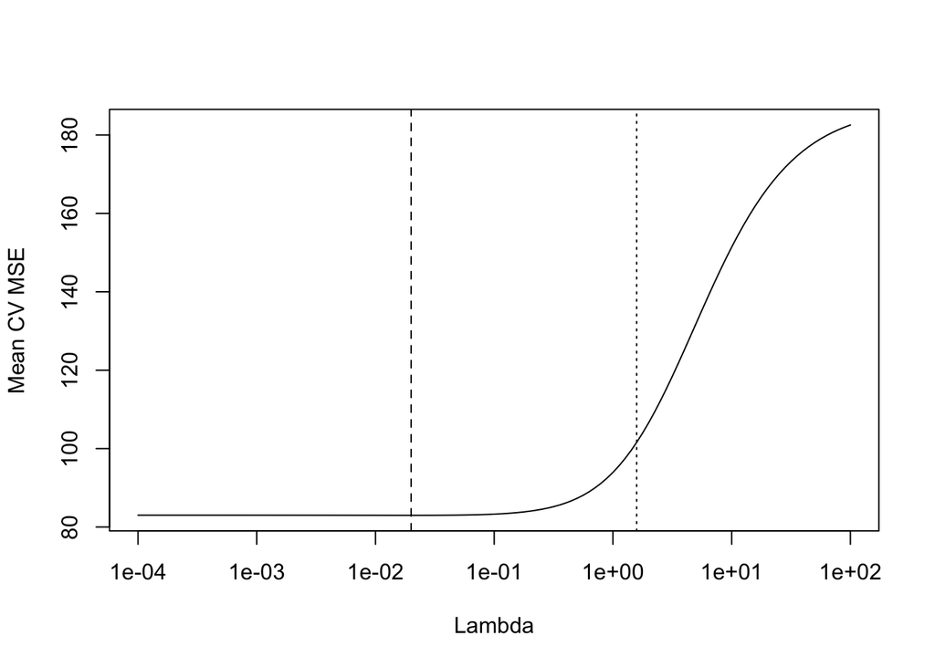

```r
abline(v = lambda_min, lty = 2)
abline(v = lambda_1se, lty = 3)
```

**Show the workflow**

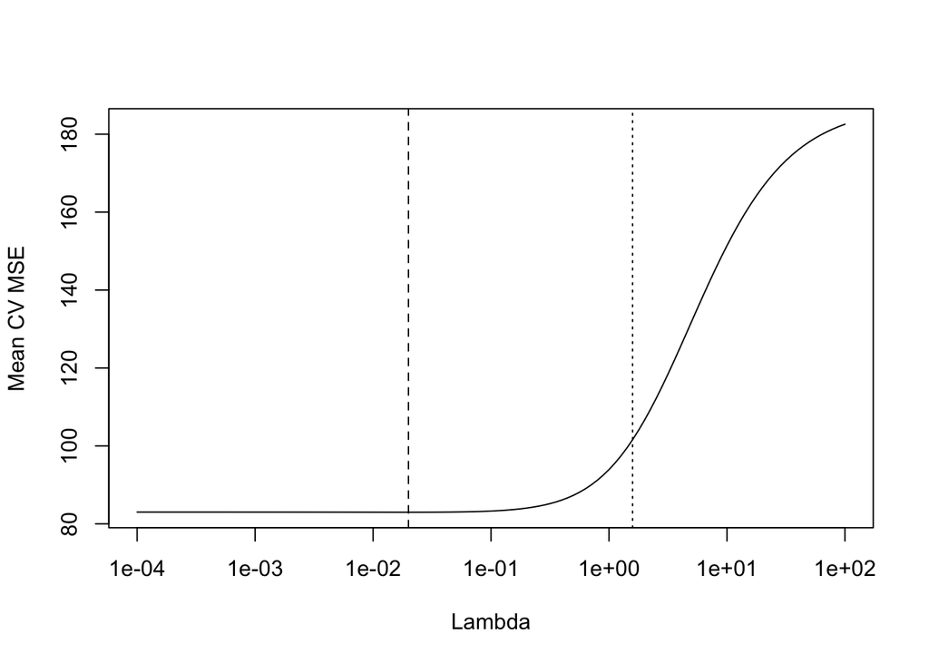

```r
plot(
  lambda_grid[-1],
  cv_mean[-1],
  type = "l",
  log = "x",
  xlab = "Lambda",
  ylab = "Mean CV MSE"
)

abline(v = lambda_min, lty = 2)
abline(v = lambda_1se, lty = 3)
```

**Show the workflow**

```r
lambda_min
```

```
[1] 0.01995262
```

**Show the workflow**

```r
lambda_1se
```

```
[1] 1.584893
```

**Show the workflow**

```r
cv_mean[min_idx]
```

```
[1] 82.97765
```

**Show the workflow**

```r
cv_se[min_idx]
```

```
[1] 19.22991
```

**Show the workflow**

```r
X_train_all_raw <- as.matrix(train_data[, predictors])
y_train_all <- train_data$price

x_bar_all <- colMeans(X_train_all_raw)
X_train_all_centered <- sweep(X_train_all_raw, 2, x_bar_all, "-")

x_scale_all <- sqrt(colMeans(X_train_all_centered^2))
X_train_all <- sweep(X_train_all_centered, 2, x_scale_all, "/")

y_bar_all <- mean(y_train_all)
y_tilde_all <- y_train_all - y_bar_all

n_train <- nrow(X_train_all)

d <- svd(X_train_all, nu = 0, nv = 0)$d

gcv <- numeric(length(lambda_grid))
df_eff <- numeric(length(lambda_grid))
train_mse_gcv <- numeric(length(lambda_grid))

for (j in 1:length(lambda_grid)) {

  lambda <- lambda_grid[j]

  beta_hat <- solve(
    t(X_train_all) %*% X_train_all +
      n_train * lambda * diag(ncol(X_train_all)),
    t(X_train_all) %*% y_tilde_all
  )

  y_hat <- y_bar_all + X_train_all %*% beta_hat

  train_mse_gcv[j] <- mean((y_train_all - y_hat)^2)

  df_eff[j] <- 1 + sum(
    d^2 / (d^2 + n_train * lambda)
  )

  gcv[j] <- train_mse_gcv[j] /
    (1 - df_eff[j] / n_train)^2
}

gcv_idx <- which.min(gcv)
lambda_GCV <- lambda_grid[gcv_idx]

lambda_GCV
```

```
[1] 0.02818383
```

**Show the workflow**

```r
gcv[gcv_idx]
```

```
[1] 83.50191
```

**Show the workflow**

```r
df_eff[gcv_idx]
```

```
[1] 6.688657
```

**Show the workflow**

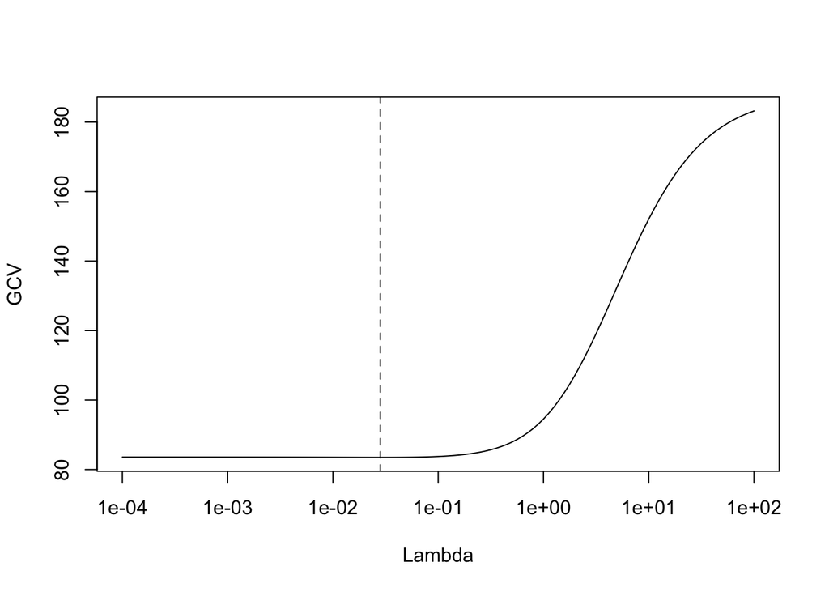

```r
plot(
  lambda_grid[-1],
  gcv[-1],
  type = "l",
  log = "x",
  xlab = "Lambda",
  ylab = "GCV"
)

abline(v = lambda_GCV, lty = 2)
```

**Show the workflow**

```r
X_test_raw <- as.matrix(test_data[, predictors])

X_test_centered <- sweep(X_test_raw, 2, x_bar_all, "-")
X_test <- sweep(X_test_centered, 2, x_scale_all, "/")

y_test <- test_data$price

final_lambdas <- c(
  OLS = 0,
  lambda_min = lambda_min,
  lambda_1se = lambda_1se,
  lambda_GCV = lambda_GCV
)

final_results <- data.frame(
  model = names(final_lambdas),
  lambda = as.numeric(final_lambdas),
  train_mse = NA_real_,
  test_mse = NA_real_,
  df_eff = NA_real_
)

for (j in 1:length(final_lambdas)) {

  lambda <- final_lambdas[j]

  beta_hat <- solve(
    t(X_train_all) %*% X_train_all +
      n_train * lambda * diag(ncol(X_train_all)),
    t(X_train_all) %*% y_tilde_all
  )

  y_hat_train <- y_bar_all + X_train_all %*% beta_hat
  y_hat_test <- y_bar_all + X_test %*% beta_hat

  final_results$train_mse[j] <-
    mean((y_train_all - y_hat_train)^2)

  final_results$test_mse[j] <-
    mean((y_test - y_hat_test)^2)

  final_results$df_eff[j] <-
    1 + sum(d^2 / (d^2 + n_train * lambda))
}

final_results
```

```
       model     lambda train_mse test_mse   df_eff
1        OLS 0.00000000  80.09392 66.32246 7.000000
2 lambda_min 0.01995262  80.13543 65.99957 6.773213
3 lambda_1se 1.58489319 100.37356 81.19981 3.032870
4 lambda_GCV 0.02818383  80.17125 65.90276 6.688657
```

The value of $\lambda$ that minimized the mean cross-validation MSE was $\lambda_{\min}=0.01995$, with a mean CV MSE of 82.98. Using the one-standard-error rule, the largest value within one standard error of the minimum was $\lambda_{1SE}=1.58489$.

The GCV criterion was minimized at $\lambda_{\text{GCV}}=0.02818$, with a minimum GCV value of 83.50. At this value of $\lambda$, the effective degrees of freedom were approximately 6.69.

The OLS, $\lambda_{\min}$, $\lambda_{1SE}$, and $\lambda_{\text{GCV}}$ models had test MSEs of 66.32, 66.00, 81.20, and 65.90, respectively. The GCV-selected model had the lowest test MSE, while the 1-SE model had the highest. However, these models were selected before looking at the test set, so the test results should only be used to evaluate the predetermined models. Choosing a new model based on these test errors would use the test set for model selection and could bias the reported test performance.

## `explain-to-me` skill

```markdown
---
name: explain-to-me
description: read and analyze STAT 432 homework questions to help me before solving them
---

# Explain to Me

When I explicitly ask you to use this skill on a STAT 432 homework question, help me understand the question without solving it for me.

1. First, locate and read the homework question from the current STAT 432 repository. Do not use an online homework page as a substitute for the local homework file.
2. Begin by explaining to me what the question is asking me to do in simple terms.
3. Identify the overarching mathematical or statistical concepts that the question is asking me to practice.
4. Break the problem into smaller, more approachable steps that I can work through myself.
5. Search https://teazrq.github.io/stat432rpy/ to find the lecture concepts that pertain to this question. Prioritize the course material over outside sources.
6. Explain unfamiliar notation, formulas, or terminology when necessary.
7. If I am struggling with a step, give me a hint or explain the relevant concept before showing me how to solve it.
```

## Reference

The real-estate data come from I-Cheng Yeh’s [Real Estate Valuation dataset](https://archive.ics.uci.edu/dataset/477/real%2Bestate%2Bvaluation%2Bda) in the UCI Machine Learning Repository. The distributed data retain the original observations and add only the course train-test and fold assignments.